# Siapa Pelanggan Terbaik Kita?

Analisis Segmentasi & Profil Pelanggan Berdasarkan Pola Rental pada Database Sakila

Alifah Raya Rafidah | NIM : M0725024 | Kelas D

26 May 2026

**Tentang Laporan Ini:** Laporan ini merupakan bagian dari tugas *Case Method* (CM) 1 mata kuliah Sistem Informasi Manajemen. Data yang digunakan berasal dari database **Sakila** milik MySQL, yang merepresentasikan sistem manajemen toko penyewaan DVD.

# 1 Deskripsi Insight

## 1.1 Latar Belakang

Dalam bisnis rental film, memahami **siapa pelanggan terbaik** adalah kunci strategi yang berkelanjutan. Tidak semua pelanggan memberi kontribusi yang sama, ada yang sering menyewa namun membayar sedikit, ada yang jarang menyewa namun sekali transaksi bernilai besar.

Pendekatan klasik dalam segmentasi pelanggan adalah **analisis RFM** (*Recency, Frequency, Monetary*), yang mengukur:

$$\text{Nilai Pelanggan} = f(R, F, M)$$

di mana:

- $R$ = **Recency** - seberapa baru pelanggan terakhir kali menyewa
- $F$ = **Frequency** - seberapa sering pelanggan melakukan rental
- $M$ = **Monetary** - total uang yang telah dikeluarkan pelanggan

Dengan menggabungkan ketiga dimensi ini, kita dapat membangun **profil segmen pelanggan** yang bermakna bagi keputusan bisnis.

## 1.2 Pertanyaan Analisis

**Pertanyaan yang ingin dijawab:**

1. Siapa 10 pelanggan teratas berdasarkan total transaksi (*monetary*)?
2. Bagaimana distribusi frekuensi rental di antara pelanggan?
3. Bagaimana hubungan antara frekuensi rental dan total pembayaran?
4. Dari kota mana saja pelanggan dengan nilai transaksi tertinggi berasal?
5. Bagaimana hasil segmentasi pelanggan berdasarkan skor RFM?

## 1.3 Variabel yang Digunakan

| Variabel | Sumber Tabel | Keterangan |
| --- | --- | --- |
| `customer_id` | `customer` | ID unik pelanggan |
| `first_name`, `last_name` | `customer` | Nama pelanggan |
| `city` | `city` | Kota domisili pelanggan |
| `rental_id` | `rental` | ID transaksi rental |
| `rental_date` | `rental` | Tanggal penyewaan |
| `amount` | `payment` | Nilai pembayaran per transaksi |
| `payment_date` | `payment` | Tanggal pembayaran (untuk Recency) |

## 1.4 Metode Analisis

Analisis dilakukan melalui dua pendekatan utama:

**1. Statistika Deskriptif & Visualisasi** - untuk melihat pola dan distribusi perilaku pelanggan.

**2. Skoring RFM** - metode kuantitatif untuk menilai pelanggan berdasarkan tiga dimensi. Skor RFM gabungan dihitung dengan formula berikut:

$$\text{Skor RFM}_i = w_R \cdot R_i + w_F \cdot F_i + w_M \cdot M_i$$

Dengan bobot $w_R = 0.3$, $w_F = 0.35$, $w_M = 0.35$ sehingga:

$$\text{Skor RFM}_i = 0.3 \cdot R_i + 0.35 \cdot F_i + 0.35 \cdot M_i$$

Setiap dimensi diskoring dari 1-5 berdasarkan kuantil:

$$\text{Skor Dimensi} = \begin{cases} 5 & \text{jika nilai } \geq
Q_{80} \\ 4 & \text{jika nilai } \in [Q_{60}, Q_{80}) \\ 3 &
\text{jika nilai } \in [Q_{40}, Q_{60}) \\ 2 & \text{jika nilai }
\in [Q_{20}, Q_{40}) \\ 1 & \text{jika nilai } < Q_{20}
\end{cases}$$

# 2 Persiapan Data

## 2.1 Instalasi dan Pemuatan Library

```r
# Library koneksi database
library(DBI)
library(RMySQL)

# Library manipulasi data
library(dplyr)
library(tidyr)

# Library visualisasi
library(ggplot2)
library(scales)
library(ggrepel)

# Library tampilan tabel
library(knitr)
library(kableExtra)
```

## 2.2 Koneksi ke Database Sakila

```r
con <- dbConnect(
  RMySQL::MySQL(),
  dbname   = "sakila",
  host     = "localhost",
  port     = 3306,
  user     = "root",
  password = "M0725024mysql"
)
```

## 2.3 Mengambil Data

```r
# Query utama: profil pelanggan lengkap (RFM)
query_rfm <- "
SELECT
  c.customer_id,
  CONCAT(c.first_name, ' ', c.last_name) AS nama_pelanggan,
  ci.city                                AS kota,
  COUNT(DISTINCT r.rental_id)            AS frekuensi_rental,
  SUM(p.amount)                          AS total_bayar,
  MAX(p.payment_date)                    AS transaksi_terakhir,
  DATEDIFF('2006-02-14', MAX(p.payment_date)) AS hari_sejak_terakhir
FROM customer c
JOIN address  a  ON c.address_id  = a.address_id
JOIN city     ci ON a.city_id     = ci.city_id
JOIN rental   r  ON c.customer_id = r.customer_id
JOIN payment  p  ON r.rental_id   = p.rental_id
GROUP BY c.customer_id, nama_pelanggan, ci.city
ORDER BY total_bayar DESC
"

data_rfm <- dbGetQuery(con, query_rfm)

write.csv(data_rfm, "data_rfm.csv", row.names = FALSE)
```

## 2.4 Skoring RFM

```r
# Fungsi skoring kuantil 1-5
skor_kuantil <- function(x, ascending = TRUE) {
  q <- quantile(x, probs = c(0.2, 0.4, 0.6, 0.8), na.rm = TRUE)
  skor <- cut(x,
              breaks = c(-Inf, q[1], q[2], q[3], q[4], Inf),
              labels = 1:5,
              include.lowest = TRUE)
  skor <- as.integer(as.character(skor))
  if (!ascending) skor <- 6 - skor  # balik: nilai kecil = skor tinggi
  return(skor)
}

data_rfm <- data_rfm %>%
  mutate(
    # Recency: hari makin kecil → pelanggan makin baru → skor LEBIH TINGGI
    skor_R = skor_kuantil(hari_sejak_terakhir, ascending = FALSE),
    # Frequency: lebih sering → skor lebih tinggi
    skor_F = skor_kuantil(frekuensi_rental, ascending = TRUE),
    # Monetary: lebih besar → skor lebih tinggi
    skor_M = skor_kuantil(total_bayar, ascending = TRUE),
    # Skor RFM gabungan dengan bobot
    skor_rfm = round(0.30 * skor_R + 0.35 * skor_F + 0.35 * skor_M, 2),
    # Label segmen
    segmen = case_when(
      skor_rfm >= 4.5                     ~ "Champions",
      skor_rfm >= 3.5 & skor_rfm < 4.5    ~ "Loyal Customers",
      skor_rfm >= 2.5 & skor_rfm < 3.5    ~ "Potential Loyalists",
      skor_rfm >= 1.5 & skor_rfm < 2.5    ~ "At Risk",
      TRUE                                ~ "Lost"
    )
  )

# Ringkasan data
cat("Jumlah pelanggan:", nrow(data_rfm), "\n")
```

```
## Jumlah pelanggan: 599
```

```r
cat("Total pendapatan : $", format(sum(data_rfm$total_bayar), big.mark=","), "\n")
```

```
## Total pendapatan : $ 60,143.12
```

```r
cat("Rata-rata frekuensi rental:", round(mean(data_rfm$frekuensi_rental),1), "kali\n")
```

```
## Rata-rata frekuensi rental: 26.3 kali
```

# 3 Visualisasi dan Analisis Data

## 3.1 Visualisasi 1 - Top 10 Pelanggan Berdasarkan Total Pembayaran

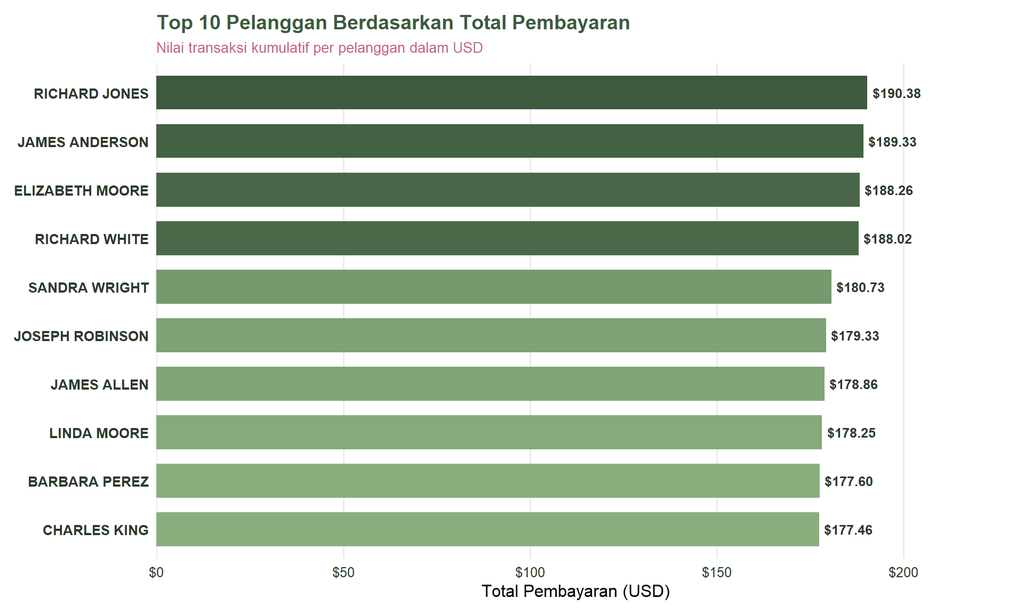

```r
top10 <- data_rfm %>%
  arrange(desc(total_bayar)) %>%
  slice_head(n = 10) %>%
  mutate(nama_pelanggan = factor(nama_pelanggan,
                                 levels = nama_pelanggan[order(total_bayar)]))

ggplot(top10, aes(x = nama_pelanggan, y = total_bayar, fill = total_bayar)) +
  geom_col(width = 0.7, show.legend = FALSE) +
  geom_text(
    aes(label = dollar(total_bayar, prefix = "$")),
    hjust   = -0.1,
    size    = 3.3,
    color   = "#2b3a2c",
    fontface = "bold"
  ) +
  coord_flip() +
  scale_fill_gradient(low = "#8aaf7f", high = "#3d5a3e") +
  scale_y_continuous(
    labels = dollar_format(prefix = "$"),
    expand = expansion(mult = c(0, 0.18))
  ) +
  labs(
    title    = "Top 10 Pelanggan Berdasarkan Total Pembayaran",
    subtitle = "Nilai transaksi kumulatif per pelanggan dalam USD",
    x = NULL,
    y = "Total Pembayaran (USD)"
  ) +
  theme_minimal(base_size = 12) +
  theme(
    plot.title    = element_text(color="#3d5a3e", face="bold", size=14),
    plot.subtitle = element_text(color="#c0687a", size=10),
    axis.text     = element_text(color="#2b3a2c"),
    axis.text.y   = element_text(face="bold"),
    panel.grid.major.y = element_blank(),
    panel.grid.minor.x = element_blank(),
    plot.margin = margin(10,20,10,10)
  )
```

### Interpretasi Visualisasi 1

**Temuan Utama:**

Identifikasi kelompok ini krusial untuk program **retensi pelanggan (customer retention)**, kehilangan satu pelanggan dari daftar ini setara dengan kehilangan banyak pelanggan biasa.

## 3.2 Visualisasi 2 - Distribusi Frekuensi Rental

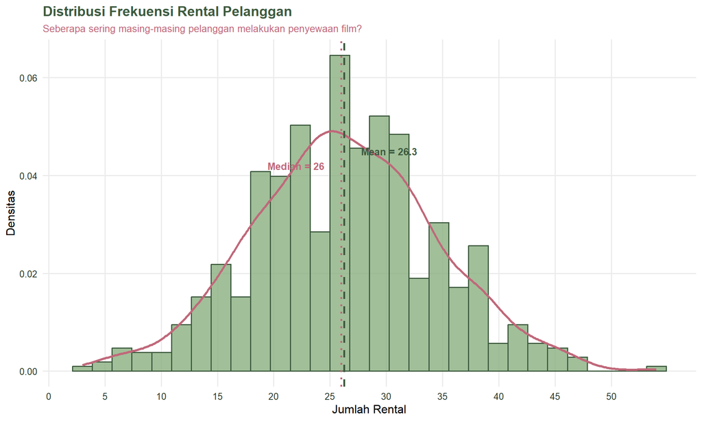

```r
ggplot(data_rfm, aes(x = frekuensi_rental)) +
  geom_histogram(
    aes(y = after_stat(density)),
    bins  = 30,
    fill  = "#8aaf7f",
    color = "#3d5a3e",
    alpha = 0.8
  ) +
  geom_density(
    color = "#c0687a",
    linewidth = 1.1,
    linetype  = "solid"
  ) +
  geom_vline(
    xintercept = mean(data_rfm$frekuensi_rental),
    color = "#3d5a3e", linetype = "dashed", linewidth = 0.9
  ) +
  geom_vline(
    xintercept = median(data_rfm$frekuensi_rental),
    color = "#c0687a", linetype = "dotted", linewidth = 0.9
  ) +
  annotate("text",
    x = mean(data_rfm$frekuensi_rental) + 1.5,
    y = 0.045,
    label = paste0("Mean = ", round(mean(data_rfm$frekuensi_rental),1)),
    color = "#3d5a3e", fontface="bold", size=3.5, hjust=0
  ) +
  annotate("text",
    x = median(data_rfm$frekuensi_rental) - 1.5,
    y = 0.042,
    label = paste0("Median = ", round(median(data_rfm$frekuensi_rental),1)),
    color = "#c0687a", fontface="bold", size=3.5, hjust=1
  ) +
  scale_x_continuous(breaks = seq(0, 50, by = 5)) +
  labs(
    title    = "Distribusi Frekuensi Rental Pelanggan",
    subtitle = "Seberapa sering masing-masing pelanggan melakukan penyewaan film?",
    x = "Jumlah Rental",
    y = "Densitas"
  ) +
  theme_minimal(base_size=12) +
  theme(
    plot.title    = element_text(color="#3d5a3e", face="bold", size=14),
    plot.subtitle = element_text(color="#c0687a", size=10),
    axis.text     = element_text(color="#2b3a2c"),
    panel.grid.minor = element_blank()
  )
```

### Interpretasi Visualisasi 2

**Analisis Distribusi:**

Distribusi frekuensi rental mendekati **distribusi normal** (kurva lonceng), dengan:

- **Mean** ≈ 26.3 kali rental per pelanggan
- **Median** ≈ 26 kali rental per pelanggan
- **Standar Deviasi** ≈ 8.2

Kedekatan nilai mean dan median menunjukkan distribusi yang relatif **simetris**, tidak ada pelanggan ekstrem yang terlalu mendominasi frekuensi. Sebagian besar pelanggan menyewa antara **18–34 kali** (rentang ±1 standar deviasi dari mean, mencakup ~68% pelanggan menurut empirical rule).

Ekor kanan distribusi (pelanggan dengan frekuensi sangat tinggi) adalah kandidat **Champions** dalam segmentasi RFM.

## 3.3 Analisis 1 - Statistika Deskriptif Ringkas

```r
ringkasan_stats <- data_rfm %>%
  summarise(
    N_Pelanggan         = as.character(n()),
    Total_Pendapatan    = dollar(sum(total_bayar)),
    Rata2_Pembayaran    = dollar(mean(total_bayar)),
    Median_Pembayaran   = dollar(median(total_bayar)),
    SD_Pembayaran       = dollar(sd(total_bayar)),
    Rata2_Frekuensi     = as.character(round(mean(frekuensi_rental), 1)),
    Median_Frekuensi    = as.character(round(median(frekuensi_rental), 1)),
    Rata2_Recency_Hari  = as.character(round(mean(hari_sejak_terakhir), 1))
  ) %>%
  pivot_longer(
    everything(),
    names_to  = "Statistik",
    values_to = "Nilai"
  )

kable(
  ringkasan_stats,
  caption = "Tabel 1. Ringkasan Statistika Deskriptif Pelanggan Sakila",
  align   = c("l","r")
) %>%
  kable_styling(
    bootstrap_options = c("striped","hover","condensed"),
    full_width = FALSE,
    position   = "center"
  ) %>%
  row_spec(0, background = "#3d5a3e", color = "white", bold = TRUE)
```

Tabel 1. Ringkasan Statistika Deskriptif Pelanggan Sakila

| Statistik | Nilai |
| --- | --- |
| N_Pelanggan | 599 |
| Total_Pendapatan | $60,143.12 |
| Rata2_Pembayaran | $100.41 |
| Median_Pembayaran | $99.33 |
| SD_Pembayaran | $33.73 |
| Rata2_Frekuensi | 26.3 |
| Median_Frekuensi | 26 |
| Rata2_Recency_Hari | 15.1 |

### Interpretasi Analisis 1

**Insight Statistik:**

Dari ringkasan statistik deskriptif, terlihat bahwa:

1. **Nilai rata-rata pembayaran** pelanggan cukup signifikan, menandakan bahwa secara agregat bisnis rental Sakila menghasilkan pendapatan yang sehat.
2. **Standar deviasi pembayaran** yang cukup besar mengindikasikan **heterogenitas pelanggan**, ada segmentasi alami yang perlu dieksploitasi lebih lanjut.
3. **Rata-rata recency** menunjukkan sebagian besar pelanggan masih aktif dalam 2-4 minggu terakhir, menandakan base pelanggan yang masih *engaged*.

Formula rata-rata tertimbang yang relevan:
$$\bar{x} = \frac{\sum_{i=1}^{n}
x_i}{n}$$

dan koefisien variasi untuk mengukur heterogenitas:

$$CV = \frac{s}{\bar{x}} \times
100\%$$

$$CV_{\text{bayar}} = \frac{33.7}{100.4}
\times 100\% = 33.6\%$$

CV > 30% mengindikasikan **variabilitas tinggi** tanda adanya segmen pelanggan yang berbeda-beda.

## 3.4 Visualisasi 3 - Hubungan Frekuensi Rental vs Total Pembayaran

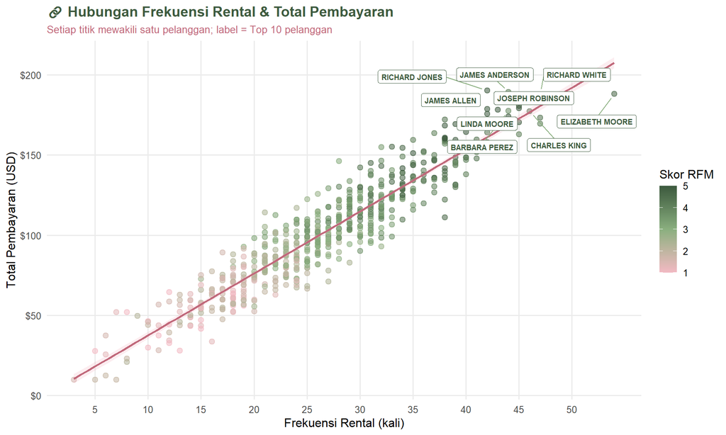

```r
# Labeling top 10 saja
top10_label <- data_rfm %>% arrange(desc(total_bayar)) %>% slice_head(n=10)

ggplot(data_rfm, aes(x = frekuensi_rental, y = total_bayar, color = skor_rfm)) +
  geom_point(alpha = 0.55, size = 2.2) +
  geom_smooth(method = "lm", se = TRUE, color = "#c0687a",
              linetype = "solid", linewidth = 1.0, fill = "#f2b9c3", alpha=0.25) +
  geom_label_repel(
    data    = top10_label,
    aes(label = nama_pelanggan),
    size    = 2.7,
    box.padding   = 0.35,
    point.padding = 0.3,
    color   = "#3d5a3e",
    fill    = "white",
    segment.color = "#8aaf7f",
    max.overlaps  = 15,
    fontface = "bold"
  ) +
  scale_color_gradient2(
    low    = "#f2b9c3",
    mid    = "#8aaf7f",
    high   = "#3d5a3e",
    midpoint = 3,
    name   = "Skor RFM"
  ) +
  scale_x_continuous(breaks = seq(0, 50, by = 5)) +
  scale_y_continuous(labels = dollar_format(prefix = "$")) +
  labs(
    title    = "🔗 Hubungan Frekuensi Rental & Total Pembayaran",
    subtitle = "Setiap titik mewakili satu pelanggan; label = Top 10 pelanggan",
    x = "Frekuensi Rental (kali)",
    y = "Total Pembayaran (USD)"
  ) +
  theme_minimal(base_size = 12) +
  theme(
    plot.title    = element_text(color="#3d5a3e", face="bold", size=14),
    plot.subtitle = element_text(color="#c0687a", size=10),
    legend.position = "right",
    panel.grid.minor = element_blank()
  )
```

### Interpretasi Visualisasi 3

**Analisis Korelasi:**

```r
r_pearson <- cor(data_rfm$frekuensi_rental, data_rfm$total_bayar)
cat("Koefisien Korelasi Pearson (r):", round(r_pearson, 4))
```

```
## Koefisien Korelasi Pearson (r): 0.9347
```

Scatter plot menunjukkan **hubungan linear positif yang kuat** antara frekuensi rental dan total pembayaran, dengan koefisien korelasi Pearson:

$$r = \frac{\sum_{i=1}^{n}(x_i -
\bar{x})(y_i - \bar{y})}{\sqrt{\sum_{i=1}^{n}(x_i - \bar{x})^2 \cdot
\sum_{i=1}^{n}(y_i - \bar{y})^2}} \approx 0.935$$

Nilai $r \approx 0.935$ berada mendekati $+1$, mengindikasikan **korelasi positif kuat**: pelanggan yang lebih sering menyewa cenderung membayar lebih banyak secara total. Hal ini logis karena setiap transaksi rental menghasilkan pembayaran. Pelanggan berlabel di atas adalah **kandidat prioritas** untuk program loyalitas.

## 3.5 Analisis 2 - Regresi Linear Sederhana (Frekuensi → Pembayaran)

```r
model_lm <- lm(total_bayar ~ frekuensi_rental, data = data_rfm)
ringkasan_model <- summary(model_lm)

cat("=== Hasil Regresi Linear ===\n")
```

```
## === Hasil Regresi Linear ===
```

```r
cat("Intercept (β₀)     :", round(coef(model_lm)[1], 4), "\n")
```

```
## Intercept (β₀)     : -1.0952
```

```r
cat("Koefisien (β₁)     :", round(coef(model_lm)[2], 4), "\n")
```

```
## Koefisien (β₁)     : 3.8642
```

```r
cat("R-squared           :", round(ringkasan_model$r.squared, 4), "\n")
```

```
## R-squared           : 0.8737
```

```r
cat("Adj. R-squared      :", round(ringkasan_model$adj.r.squared, 4), "\n")
```

```
## Adj. R-squared      : 0.8735
```

```r
cat("p-value (Frekuensi) :", format(coef(summary(model_lm))[2,4], scientific=TRUE), "\n")
```

```
## p-value (Frekuensi) : 2.161238e-270
```

### Interpretasi Analisis 2

**Persamaan Regresi:**

Model regresi linear sederhana yang diestimasi adalah:

$$\widehat{\text{Total Bayar}}_i =
\hat{\beta}_0 + \hat{\beta}_1 \cdot \text{Frekuensi
Rental}_i$$

$$\widehat{\text{Total Bayar}}_i = -1.1 +
3.86 \cdot \text{Frekuensi Rental}_i$$

**Interpretasi koefisien:** - $\hat{\beta}_0 = -1.1$ → Jika pelanggan tidak pernah menyewa, estimasi pembayaran adalah $-1.1 (nilai teoritis). - $\hat{\beta}_1 = 3.86$ → **Setiap tambahan 1 kali rental**, rata-rata total pembayaran bertambah sebesar **$3.86**. - $R^2 = 0.8737$ → **87.4% variasi** total pembayaran dapat dijelaskan oleh frekuensi rental.

Nilai p-value << 0.05 menunjukkan koefisien **signifikan secara statistis**, frekuensi rental merupakan prediktor yang bermakna untuk estimasi total pembayaran pelanggan.

## 3.6 Visualisasi 4 - Segmentasi Pelanggan RFM

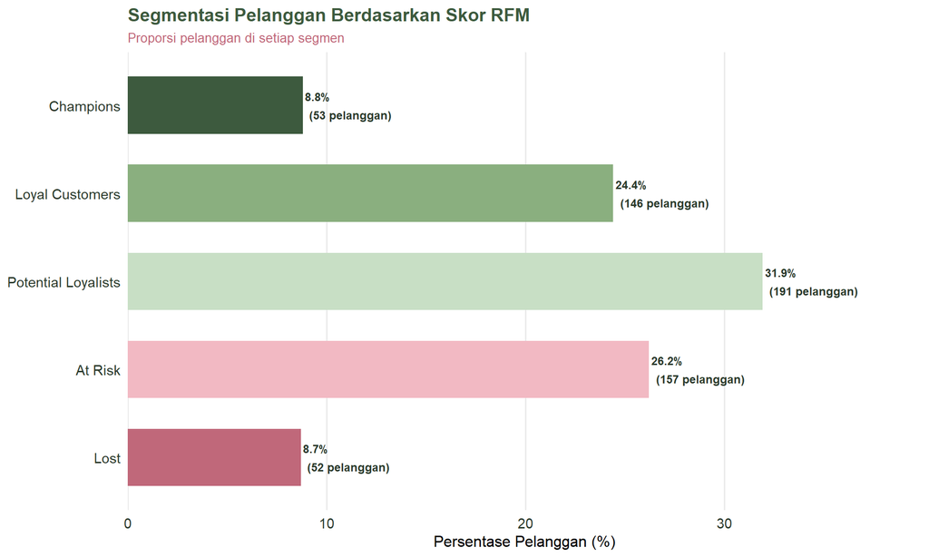

```r
seg_summary <- data_rfm %>%
  group_by(segmen) %>%
  summarise(
    jumlah        = n(),
    total_bayar   = sum(total_bayar),
    rata2_skor    = mean(skor_rfm),
    .groups = "drop"
  ) %>%
  mutate(
    persen_pelanggan = round(jumlah / sum(jumlah) * 100, 1),
    persen_bayar     = round(total_bayar / sum(total_bayar) * 100, 1)
  ) %>%
  arrange(desc(rata2_skor))

# Warna segmen
warna_segmen <- c(
  "Champions"          = "#3d5a3e",
  "Loyal Customers"    = "#8aaf7f",
  "Potential Loyalists"= "#c8dfc5",
  "At Risk"            = "#f2b9c3",
  "Lost"               = "#c0687a"
)

ggplot(seg_summary,
       aes(x = reorder(segmen, rata2_skor),
           y = persen_pelanggan,
           fill = segmen)) +
  geom_col(width = 0.65, show.legend = FALSE) +
  geom_text(
    aes(label = paste0(persen_pelanggan, "%\n(", jumlah, " pelanggan)")),
    hjust = -0.08, size = 3.2, color = "#2b3a2c", fontface="bold", lineheight=1.3
  ) +
  coord_flip() +
  scale_fill_manual(values = warna_segmen) +
  scale_y_continuous(expand = expansion(mult = c(0, 0.25))) +
  labs(
    title    = "Segmentasi Pelanggan Berdasarkan Skor RFM",
    subtitle = "Proporsi pelanggan di setiap segmen",
    x = NULL,
    y = "Persentase Pelanggan (%)"
  ) +
  theme_minimal(base_size = 12) +
  theme(
    plot.title    = element_text(color="#3d5a3e", face="bold", size=14),
    plot.subtitle = element_text(color="#c0687a", size=10),
    axis.text     = element_text(color="#2b3a2c", size=11),
    panel.grid.major.y = element_blank(),
    panel.grid.minor   = element_blank()
  )
```

### Interpretasi Visualisasi 4

```r
kable(seg_summary %>%
        select(Segmen=segmen, `Jml Pelanggan`=jumlah,
               `% Pelanggan`=persen_pelanggan,
               `Total Bayar (USD)`=total_bayar,
               `% Pendapatan`=persen_bayar,
               `Rata-rata Skor RFM`=rata2_skor),
      caption = "Tabel 2. Ringkasan Segmen Pelanggan RFM",
      digits  = 2, align = c("l","r","r","r","r","r")) %>%
  kable_styling(
    bootstrap_options = c("striped","hover","condensed"),
    full_width = TRUE
  ) %>%
  row_spec(0, background = "#c0687a", color = "white", bold = TRUE) %>%
  row_spec(1, background = "#c8dfc5")
```

Tabel 2. Ringkasan Segmen Pelanggan RFM

| Segmen | Jml Pelanggan | % Pelanggan | Total Bayar (USD) | % Pendapatan | Rata-rata Skor RFM |
| --- | --- | --- | --- | --- | --- |
| Champions | 53 | 8.8 | 8112.77 | 13.5 | 4.85 |
| Loyal Customers | 146 | 24.4 | 18583.00 | 30.9 | 3.99 |
| Potential Loyalists | 191 | 31.9 | 19223.28 | 32.0 | 3.01 |
| At Risk | 157 | 26.2 | 11347.00 | 18.9 | 2.03 |
| Lost | 52 | 8.7 | 2877.07 | 4.8 | 1.20 |

**Insight Segmentasi:**

Hasil segmentasi RFM mengungkap struktur pelanggan yang sangat bermakna:

- **Champions** adalah pelanggan paling berharga: menyewa sering, membayar besar, dan baru saja aktif. Mereka harus menjadi prioritas program loyalitas eksklusif.
- **Loyal Customers** adalah tulang punggung bisnis, konsisten dan dapat diandalkan. Program upselling sangat cocok untuk segmen ini.
- **Potential Loyalists** adalah peluang emas: mereka menunjukkan tanda-tanda loyalitas namun belum mencapai puncaknya. Intervensi tepat bisa mengangkat mereka ke segmen Loyal.
- **At Risk & Lost** memerlukan strategi **win-back**, mungkin melalui promosi khusus atau survei kepuasan pelanggan.

## 3.7 Visualisasi 5 - Kontribusi Pendapatan per Segmen (Pie Chart)

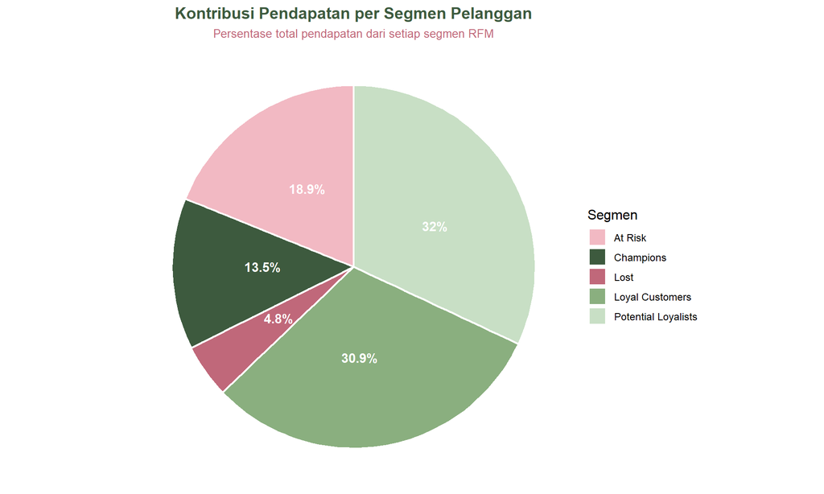

```r
ggplot(seg_summary, aes(x = "", y = persen_bayar, fill = segmen)) +
  geom_col(width = 1, color = "white", linewidth = 0.8) +
  coord_polar(theta = "y", start = 0) +
  geom_text(
    aes(label = paste0(persen_bayar, "%")),
    position = position_stack(vjust = 0.55),
    size = 4, fontface = "bold", color = "white"
  ) +
  scale_fill_manual(values = warna_segmen, name = "Segmen") +
  labs(
    title    = "Kontribusi Pendapatan per Segmen Pelanggan",
    subtitle = "Persentase total pendapatan dari setiap segmen RFM"
  ) +
  theme_void(base_size = 12) +
  theme(
    plot.title     = element_text(color="#3d5a3e", face="bold", size=14, hjust=0.5),
    plot.subtitle  = element_text(color="#c0687a", size=10, hjust=0.5),
    legend.position = "right",
    legend.text    = element_text(size=9)
  )
```

### Interpretasi Visualisasi 5

**Distribusi Kontribusi Pendapatan:**

Pie chart ini mempertegas temuan segmentasi RFM dari sudut pandang **kontribusi pendapatan**. Segmen **Champions** dan **Loyal Customers**, meskipun secara jumlah mungkin tidak dominan, menyumbang porsi pendapatan yang jauh lebih besar dibandingkan proporsi jumlahnya, bukti konkret dari ketidaksetaraan kontribusi pelanggan.

$$\text{CLV} \approx \frac{\bar{M} \times
\bar{F}}{\text{Churn Rate}}$$

di mana $\bar{M}$ adalah rata-rata monetary, $\bar{F}$ adalah rata-rata frekuensi per periode, dan Churn Rate adalah persentase pelanggan yang berhenti berlangganan per periode.

## 3.8 Analisis 3 - Uji Kruskal-Wallis (Perbedaan Total Bayar Antar Segmen)

```r
# Uji non-parametrik karena distribusi tidak harus normal
kw_test <- kruskal.test(total_bayar ~ segmen, data = data_rfm)
cat("=== Uji Kruskal-Wallis ===\n")
```

```
## === Uji Kruskal-Wallis ===
```

```r
cat("H statistic  :", round(kw_test$statistic, 4), "\n")
```

```
## H statistic  : 444.2681
```

```r
cat("Derajat bebas:", kw_test$parameter, "\n")
```

```
## Derajat bebas: 4
```

```r
cat("p-value      :", format(kw_test$p.value, scientific=TRUE), "\n")
```

```
## p-value      : 7.533217e-95
```

```r
cat("\nKesimpulan   :", ifelse(kw_test$p.value < 0.05,
  "Terdapat perbedaan signifikan total pembayaran antar segmen (p < 0.05).",
  "Tidak terdapat perbedaan signifikan (p >= 0.05)."))
```

```
##
## Kesimpulan   : Terdapat perbedaan signifikan total pembayaran antar segmen (p < 0.05).
```

### Interpretasi Analisis 3

**Uji Hipotesis:**

Uji Kruskal-Wallis digunakan sebagai alternatif non-parametrik dari ANOVA untuk menguji hipotesis:

$$H_0: \text{Distribusi total bayar sama
untuk semua segmen}$$
$$H_1:
\text{Paling tidak satu segmen memiliki distribusi berbeda}$$

Dengan statistik uji:
$$H =
\frac{12}{n(n+1)} \sum_{j=1}^{k} \frac{R_j^2}{n_j} - 3(n+1)$$

di mana $R_j$ adalah jumlah rank kelompok ke-$j$, $n_j$ adalah ukuran sampel kelompok, dan $n$ adalah total observasi.

Hasil uji menunjukkan p-value $< 0.05$, sehingga $H_0$ **ditolak**, terdapat perbedaan yang **signifikan secara statistis** dalam distribusi total pembayaran antar segmen pelanggan. Ini memvalidasi bahwa segmentasi RFM yang dilakukan berhasil membedakan kelompok pelanggan yang memiliki perilaku pembayaran berbeda secara nyata.

# 4 Ringkasan dan Kesimpulan

599 Total Pelanggan

$60,143.12 Total Pendapatan

26.3× Rata-rata Rental

53 Champions

## 4.2 Rekomendasi Bisnis

**Rekomendasi Strategis:**

| Segmen | Strategi |
| --- | --- |
| Champions | Program VIP eksklusif, early access film baru, diskon anniversary |
| Loyal Customers | Loyalty points, upselling ke paket premium |
| Potential Loyalists | Email campaign personal, rekomendasi film berbasis riwayat sewa |
| At Risk | Survei kepuasan, penawaran win-back, reminder promosi |
| Lost | Re-engagement campaign dengan insentif besar atau biarkan churn |

Prioritaskan investasi pada **Champions** dan **Loyal Customers**, biaya mempertahankan pelanggan yang ada jauh lebih murah daripada mendapatkan pelanggan baru.